# SI 370 - Homework #5: Classifiers

or: How I Learned to Stop Worrying and Love Machine Learning

Version 2023.11.06.1.CT

This is, perhaps, one of the most exciting homework assignments that you have encountered in this course!

Similar to what we introduced you to last class, you are going to try your hand at a Kaggle competition to predict which passengers onboard the Spaceship Titanic will be transported to an alternate dimension.

(NOTE: if you prefer to not submit your work to the Kaggle competition that's fine -- just contact Chris via email (cteplovs@umich.edu) and we will work out an alternative.)

To start navigate to the [Spaceship Titanic](https://www.kaggle.com/competitions/spaceship-titanic) project page.

The basic steps for this assignment were outlined in the video from last class:

1. Accept the rules and join the competition
2. Download the data (from the data tab of the competition page)
3. Understand the problem
4. EDA (Exploratory Data Analysis)
5. Train, tune, and ensemble (!) your machine learning models
6. Upload your prediction as a submission on Kaggle and receive an accuracy score

additionally, you will

7. Upload your final notebook to Canvas and report your best accuracy score.

Note that class grades are not entirely dependent on your accuracy score.  
All models that achieve 80% accuracy will receive full points for the accuracy component of this assignment.

Some additional notes:

1. If you use another notebook, code, or approaches be sure to reference the original work. (Note that we recommend you study existing Kaggle notebooks before starting your own work.)
2. If you use ChatGPT, or any other generative AI helper, be sure to reference that as well.
3. You can help each other but in the end you must submit your own work, both to Kaggle and to Canvas.

Some additional resources:

- "ensemble" your models with a [VotingClassifier](https://scikit-learn.org/stable/modules/generated/sklearn.ensemble.VotingClassifier.html)
- a good primer on [feature engineering](https://triangleinequality.wordpress.com/2013/09/08/basic-feature-engineering-with-the-titanic-data/)
- There are a lot of good [notebooks to study](https://www.kaggle.com/competitions/spaceship-titanic/code) (check the number of upvotes to help guide your exploration)

## GOOD LUCK!

(and don't cheat... cheating on this assignment will result in a grade of zero.)

One final note: Your submission should be a self-contained notebook that is NOT based on this one. Studying the existing Kaggle competition notebooks should give you a sense of what makes a "good" notebook.

```python
#import necessary packages
import pandas as pd
import numpy as np
import seaborn as sns
import matplotlib as plt
import missingno as msno

from sklearn.model_selection import cross_val_score
from sklearn.model_selection import GridSearchCV

from sklearn.metrics import accuracy_score
from sklearn.metrics import confusion_matrix
from sklearn.metrics import classification_report

from sklearn.linear_model import LogisticRegression
from sklearn.tree import DecisionTreeClassifier
from sklearn.ensemble import RandomForestClassifier
from sklearn.svm import SVC
from sklearn.ensemble import AdaBoostClassifier
from sklearn.ensemble import GradientBoostingClassifier
from sklearn.ensemble import VotingClassifier
```

```python
#load data
train_data = pd.read_csv('../homework/homework 5 data/train.csv')
test_data = pd.read_csv('../homework/homework 5 data/test.csv')
sample_submission_data = pd.read_csv('../homework/homework 5 data/sample_submission.csv')
```

```python
test_data.head()
# msno.matrix(test_data)
```

|  | PassengerId | HomePlanet | CryoSleep | Cabin | Destination | Age | VIP | RoomService | FoodCourt | ShoppingMall | Spa | VRDeck | Name |
| --- | --- | --- | --- | --- | --- | --- | --- | --- | --- | --- | --- | --- | --- |
| 0 | 0013_01 | Earth | True | G/3/S | TRAPPIST-1e | 27.0 | False | 0.0 | 0.0 | 0.0 | 0.0 | 0.0 | Nelly Carsoning |
| 1 | 0018_01 | Earth | False | F/4/S | TRAPPIST-1e | 19.0 | False | 0.0 | 9.0 | 0.0 | 2823.0 | 0.0 | Lerome Peckers |
| 2 | 0019_01 | Europa | True | C/0/S | 55 Cancri e | 31.0 | False | 0.0 | 0.0 | 0.0 | 0.0 | 0.0 | Sabih Unhearfus |
| 3 | 0021_01 | Europa | False | C/1/S | TRAPPIST-1e | 38.0 | False | 0.0 | 6652.0 | 0.0 | 181.0 | 585.0 | Meratz Caltilter |
| 4 | 0023_01 | Earth | False | F/5/S | TRAPPIST-1e | 20.0 | False | 10.0 | 0.0 | 635.0 | 0.0 | 0.0 | Brence Harperez |

```python
#Exploratory Data Analysis
train_data.describe()
```

|  | Age | RoomService | FoodCourt | ShoppingMall | Spa | VRDeck |
| --- | --- | --- | --- | --- | --- | --- |
| count | 8514.000000 | 8512.000000 | 8510.000000 | 8485.000000 | 8510.000000 | 8505.000000 |
| mean | 28.827930 | 224.687617 | 458.077203 | 173.729169 | 311.138778 | 304.854791 |
| std | 14.489021 | 666.717663 | 1611.489240 | 604.696458 | 1136.705535 | 1145.717189 |
| min | 0.000000 | 0.000000 | 0.000000 | 0.000000 | 0.000000 | 0.000000 |
| 25% | 19.000000 | 0.000000 | 0.000000 | 0.000000 | 0.000000 | 0.000000 |
| 50% | 27.000000 | 0.000000 | 0.000000 | 0.000000 | 0.000000 | 0.000000 |
| 75% | 38.000000 | 47.000000 | 76.000000 | 27.000000 | 59.000000 | 46.000000 |
| max | 79.000000 | 14327.000000 | 29813.000000 | 23492.000000 | 22408.000000 | 24133.000000 |

```python
train_data.info()
# type(train_data.VIP[1])
```

```
<class 'pandas.core.frame.DataFrame'>
RangeIndex: 8693 entries, 0 to 8692
Data columns (total 14 columns):
 #   Column        Non-Null Count  Dtype
---  ------        --------------  -----
 0   PassengerId   8693 non-null   object
 1   HomePlanet    8492 non-null   object
 2   CryoSleep     8476 non-null   object
 3   Cabin         8494 non-null   object
 4   Destination   8511 non-null   object
 5   Age           8514 non-null   float64
 6   VIP           8490 non-null   object
 7   RoomService   8512 non-null   float64
 8   FoodCourt     8510 non-null   float64
 9   ShoppingMall  8485 non-null   float64
 10  Spa           8510 non-null   float64
 11  VRDeck        8505 non-null   float64
 12  Name          8493 non-null   object
 13  Transported   8693 non-null   bool
dtypes: bool(1), float64(6), object(7)
memory usage: 891.5+ KB
```

```python
ct1 = pd.crosstab(train_data['CryoSleep'], train_data['Transported'], normalize='all')
ct1
```

| Transported CryoSleep | False | True |
| --- | --- | --- |
| False | 0.430628 | 0.211067 |
| True | 0.065361 | 0.292945 |

```python
ct2 = pd.crosstab(train_data['VIP'], train_data['Transported'], normalize='all')
ct2
```

| Transported VIP | False | True |
| --- | --- | --- |
| False | 0.482097 | 0.494464 |
| True | 0.014488 | 0.008952 |

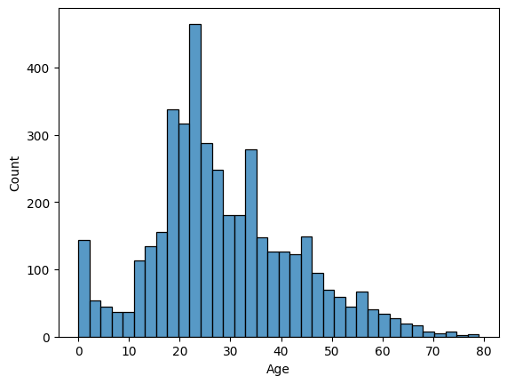

```python
sns.histplot(test_data['Age'])
```

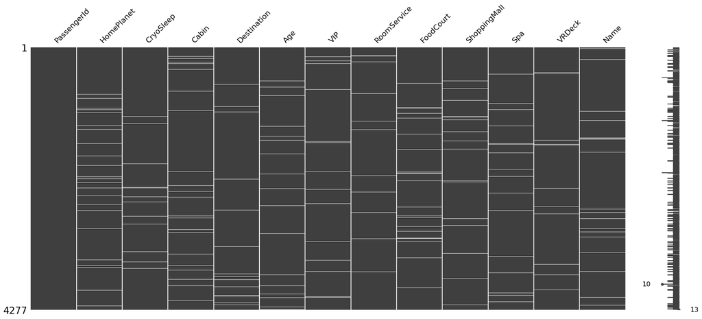

```python
#checking columns for missing values
msno.matrix(test_data)
```

```python
# sns.pairplot(data=train_data, hue='Transported')
```

```python
train_data.head()
```

|  | PassengerId | HomePlanet | CryoSleep | Cabin | Destination | Age | VIP | RoomService | FoodCourt | ShoppingMall | Spa | VRDeck | Name | Transported |
| --- | --- | --- | --- | --- | --- | --- | --- | --- | --- | --- | --- | --- | --- | --- |
| 0 | 0001_01 | Europa | False | B/0/P | TRAPPIST-1e | 39.0 | False | 0.0 | 0.0 | 0.0 | 0.0 | 0.0 | Maham Ofracculy | False |
| 1 | 0002_01 | Earth | False | F/0/S | TRAPPIST-1e | 24.0 | False | 109.0 | 9.0 | 25.0 | 549.0 | 44.0 | Juanna Vines | True |
| 2 | 0003_01 | Europa | False | A/0/S | TRAPPIST-1e | 58.0 | True | 43.0 | 3576.0 | 0.0 | 6715.0 | 49.0 | Altark Susent | False |
| 3 | 0003_02 | Europa | False | A/0/S | TRAPPIST-1e | 33.0 | False | 0.0 | 1283.0 | 371.0 | 3329.0 | 193.0 | Solam Susent | False |
| 4 | 0004_01 | Earth | False | F/1/S | TRAPPIST-1e | 16.0 | False | 303.0 | 70.0 | 151.0 | 565.0 | 2.0 | Willy Santantines | True |

```python
labels = train_data['Transported']
features = train_data.drop(['Transported','Name','PassengerId','Cabin'], axis=1)
```

```python
from sklearn.pipeline import Pipeline

cats = features.select_dtypes(include=['object']).columns
nums = features.select_dtypes(exclude=['object']).columns

from sklearn.impute import SimpleImputer
from sklearn.preprocessing import OneHotEncoder
from sklearn.preprocessing import StandardScaler
cat_pipe = Pipeline([('imputer', SimpleImputer(strategy='most_frequent')), ('encoder', OneHotEncoder())])
num_pipe = Pipeline([('imputer', SimpleImputer(strategy='median')), ('scaler', StandardScaler())])
```

```python
from sklearn.compose import ColumnTransformer
```

```python
ct = ColumnTransformer([('cat', cat_pipe, cats), ('num', num_pipe, nums)])
```

```python
features.head()
```

|  | HomePlanet | CryoSleep | Destination | Age | VIP | RoomService | FoodCourt | ShoppingMall | Spa | VRDeck |
| --- | --- | --- | --- | --- | --- | --- | --- | --- | --- | --- |
| 0 | Europa | False | TRAPPIST-1e | 39.0 | False | 0.0 | 0.0 | 0.0 | 0.0 | 0.0 |
| 1 | Earth | False | TRAPPIST-1e | 24.0 | False | 109.0 | 9.0 | 25.0 | 549.0 | 44.0 |
| 2 | Europa | False | TRAPPIST-1e | 58.0 | True | 43.0 | 3576.0 | 0.0 | 6715.0 | 49.0 |
| 3 | Europa | False | TRAPPIST-1e | 33.0 | False | 0.0 | 1283.0 | 371.0 | 3329.0 | 193.0 |
| 4 | Earth | False | TRAPPIST-1e | 16.0 | False | 303.0 | 70.0 | 151.0 | 565.0 | 2.0 |

```python
transformed_features = ct.fit_transform(features)
```

```python
transformed_features
transformed_features.shape
```

```
(8693, 16)
```

```python
clf = LogisticRegression()
clf.fit(transformed_features, labels)
clf.score(transformed_features, labels)
```

```
0.7863798458529851
```

```python
clfs = [LogisticRegression(), DecisionTreeClassifier(), RandomForestClassifier(), SVC(), AdaBoostClassifier(), GradientBoostingClassifier()]
for clf in clfs:
    print(clf.__class__.__name__, cross_val_score(clf, transformed_features, labels, cv=5).mean())
```

```
LogisticRegression 0.785460209860964
DecisionTreeClassifier 0.7396750642374128
RandomForestClassifier 0.7848856961165067
SVC 0.7889130493762866
AdaBoostClassifier 0.7868418353470872
GradientBoostingClassifier 0.7925943841645431
```

```python
vc = VotingClassifier([('lr', LogisticRegression()), ('dt', DecisionTreeClassifier()), ('rf', RandomForestClassifier()), ('svc', SVC()), ('ada', AdaBoostClassifier()), ('gb', GradientBoostingClassifier())])
cross_val_score(vc, transformed_features, labels, cv=5).mean()
```

```
0.792478184425397
```

```python
test_features = test_data.drop(['Name','PassengerId','Cabin'], axis=1)
test_features_transformed = ct.transform(test_features)
```

```python
vc.fit(transformed_features, labels)
test_predictions = vc.predict(test_features_transformed)
```

```python
test_predictions
```

```
array([ True, False,  True, ...,  True,  True,  True])
```

```python
sample_submission_data.head()
```

|  | PassengerId | Transported |
| --- | --- | --- |
| 0 | 0013_01 | False |
| 1 | 0018_01 | False |
| 2 | 0019_01 | False |
| 3 | 0021_01 | False |
| 4 | 0023_01 | False |

```python
sample_submission_data['Transported'] = test_predictions
sample_submission_data.to_csv('submission.csv', index=False)
```